# CSE204 - Introduction to Machine Learning - Lab Session 2: parametric models

## Example

### Exercise 2

#### Question 1

Use the previous equations to compute **by hand** (i.e. on a sheet of paper) the optimal parameters $\theta_0$ and $\theta_1$ of the model $y = \theta_0 + \theta_1 x$ to best fit the following dataset (of four observations):

$$\mathcal{D} = \left\{ \begin{pmatrix} 2 \\ 1 \end{pmatrix}, \begin{pmatrix} 5 \\ 2 \end{pmatrix}, \begin{pmatrix} 7 \\ 3 \end{pmatrix}, \begin{pmatrix} 8 \\ 3 \end{pmatrix} \right\}$$

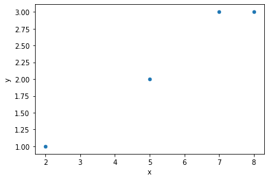

```python
X = [2, 5, 7, 8]
y = [1, 2, 3, 3]

plot_ex2(X, y)
```

Using matrices, the problem is defined as follow:

$$ \boldsymbol{y} = \begin{pmatrix} 1 \\ 2 \\ 3 \\ 3 \end{pmatrix} \quad \boldsymbol{X} = \begin{pmatrix} 1 & 2 \\ 1 & 5 \\ 1 & 7 \\ 1 & 8 \end{pmatrix} \quad \boldsymbol{\theta} = \begin{pmatrix} \theta_0 \\ \theta_1 \end{pmatrix} $$

The optimal parameter $\boldsymbol{\theta}^*$ according to the least squares is:

$$\boldsymbol{\theta}^* = (\boldsymbol{X}^T\boldsymbol{X})^{-1} \boldsymbol{X}^T\boldsymbol{y}$$

Thus we have:

$$ \boldsymbol{X}^T\boldsymbol{X} = \begin{pmatrix} 1 & 1 & 1 & 1 \\ 2 & 5 & 7 & 8 \end{pmatrix} \begin{pmatrix} 1 & 2 \\ 1 & 5 \\ 1 & 7 \\ 1 & 8 \end{pmatrix} = \begin{pmatrix} 4 & 22 \\ 22 & 142 \end{pmatrix} $$$$ \det (\boldsymbol{X}^T\boldsymbol{X}) = \det \begin{pmatrix} 4 & 22 \\ 22 & 142 \end{pmatrix} = 4 \times 142 - 22 \times 22 = 84 $$$$ (\boldsymbol{X}^T\boldsymbol{X})^{-1} = \frac{1}{84} \begin{pmatrix} 142 & -22 \\ -22 & 4 \end{pmatrix} $$$$ \boldsymbol{X}^T\boldsymbol{y} = \begin{pmatrix} 1 & 1 & 1 & 1 \\ 2 & 5 & 7 & 8 \end{pmatrix} \begin{pmatrix} 1 \\ 2 \\ 3 \\ 3 \end{pmatrix} = \begin{pmatrix} 9 \\ 57 \end{pmatrix} $$

Then the normal equation is:

\begin{align} \begin{pmatrix} \theta_0^* \\ \theta_1^* \end{pmatrix} & = \begin{pmatrix} 4 & 22 \\ 22 & 142 \end{pmatrix}^{-1} \begin{pmatrix} 9 \\ 57 \end{pmatrix} \\ & = \frac{1}{84} \begin{pmatrix} 142 & -22 \\ -22 & 4 \end{pmatrix} \begin{pmatrix} 9 \\ 57 \end{pmatrix} \\ & = \frac{1}{84} \begin{pmatrix} 24 \\ 30 \end{pmatrix} \\ & = \begin{pmatrix} 2/7 \\ 5/14 \end{pmatrix} \end{align}

The equation of the model is:

$$y = \frac{2}{7} + \frac{5}{14} x$$

#### Question 2

Check graphically that the model you obtained fits the data well using the following cell (uncomment and complete the first two lines and uncomment the last one).

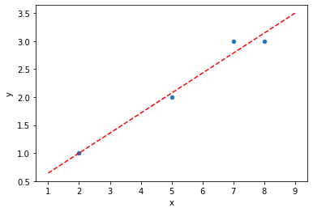

```python
X = [2, 5, 7, 8]
y = [1, 2, 3, 3]

#theta_0 =                          # <- TO UNCOMMENT AND TO COMPLETE (intercept)
#theta_1 =                          # <- TO UNCOMMENT AND TO COMPLETE (slope)

#plot_ex2(X, y, theta_0, theta_1)   # <- TO UNCOMMENT

### BEGIN SOLUTION
theta_0 = 2./7.
theta_1 = 5./14.
plot_ex2(X, y, theta_0, theta_1)
### END SOLUTION
```

```python
### BEGIN HIDDEN TESTS
from nose.tools import assert_equal
assert_equal(theta_0, 2./7.)
assert_equal(theta_1, 5./14.)
### END HIDDEN TESTS
```

#### Question 3

Plot the MSE $E(\theta)$ with the following cells. What is plotted? What is the input space and the output space?

What can you say about these plots?

```python
X = np.array([[1, 1, 1, 1], [2, 5, 7, 8]]).T
y = np.array([1, 2, 3, 3]).reshape(-1, 1)
```

```python
class MSE:
    def __init__(self, X, y):
        self.X = np.copy(X)
        self.y = np.copy(y)

    def __call__(self, theta):
        return 1./2. * ((np.tile(self.y, theta.shape[1]) - np.dot(self.X, theta))**2).sum(axis=0)

mse = MSE(X, y)
```

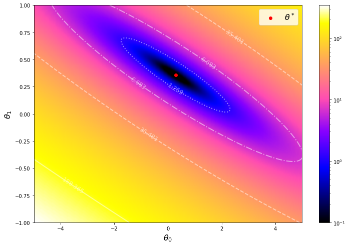

```python
plot_contour_2d_solution_space(mse,
                               theta_min=np.array([-5, -1]),
                               theta_max=np.array([5, 1]),
                               theta_star=np.array([[theta_0], [theta_1]]));
```

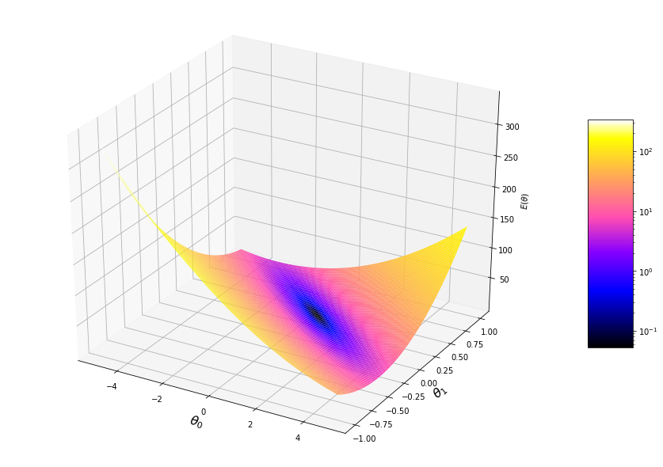

```python
plot_2d_solution_space(mse,
                       theta_min=np.array([-5, -1]),
                       theta_max=np.array([5, 1]));
```

These plots show the error with respect to parameters $\theta_0$ and $\theta_1$ (the *solution space*). The color bar on the right gives the error $E(\boldsymbol{\theta})$ associated to each color ($\boldsymbol{\theta}$ vectors in the yellow area have high error whereas $\boldsymbol{\theta}$ vectors in the black area have low error).

This plot confirms again that the smallest error is obtained for $\begin{pmatrix} \theta_0 \\ \theta_1 \end{pmatrix} = \begin{pmatrix} 2/7 \\ 5/14 \end{pmatrix} \approx \begin{pmatrix} 0.29 \\ 0.36 \end{pmatrix}$.

## Linear regression: an approximated solution using a *gradient descent* method

When $(X^TX)^{-1}$ cannot be easily computed (e.g. no analytical solution or $\mathcal{D}$ contains a lot of examples or the dimension of the solution space $\mathcal{X}$ is too large), an approximated solution can be computed using a *gradient descent method*.

$\nabla_{\theta}E(\hat{\theta})$ gives the direction of the largest slope at the point $\hat{\theta}$. Thus, if we explore iteratively the parameter space by following the opposite direction of this gradient as described in the following definition, we should converge to the parameter $\theta^*$ that minimizes the MSE, i.e. the parameter $\theta^*$ such that $\nabla_{\theta^*}E(\hat{\theta^*}) = 0$.

Starting from a random point $\theta$, the gradient descent method proposes a new point $\theta \leftarrow \theta - \eta \nabla_{\theta}E(\theta)$ at each iteration until a stopping criterion has been reached: e.g. $||\nabla_{\theta}E(\theta)||_2^2 > \epsilon_{\delta}$ with $\epsilon_{\delta}$ a chosen minimal length for the gradient to continue iterations.

The *learning rate* $\eta \in \mathbb{R}_+^*$ is a parameter to tweak for the considered problem.

- If $\eta$ is too large, the optimization may not converge toward 0.
- If $\eta$ is too small, the optimization may require a lot of iterations to converge.

### Exercise 3

#### Question 1

Implement a gradient descent method to solve exercise 2 with an approximated solution. Use the analytic formulation of $\nabla_{\theta}E(\theta)$ that has been computed in exercise 1.

You can use a very basic stopping criteria: the number of iterations (e.g. 10000). You can start with $\eta = 0.001$.

Here we have: $$ \boldsymbol{y} = \begin{pmatrix} 1 \\ 2 \\ 3 \\ 3 \end{pmatrix} \quad \boldsymbol{X} = \begin{pmatrix} 1 & 2 \\ 1 & 5 \\ 1 & 7 \\ 1 & 8 \end{pmatrix} \quad \boldsymbol{\theta} = \begin{pmatrix} \theta_0 \\ \theta_1 \end{pmatrix} $$